# Analiza gatunków Irysa: Setosa, Virginica i Versicolor

## KROK 1 EDA

#### Ogolne informacje o danych:

[figure not shown]

|  | długość kielicha (sepal length) | szerokość kielicha (sepal width) | długość płatka (petal length) | szerokość płatka (petal width) | klasa (class) |
| --- | --- | --- | --- | --- | --- |
| 0 | 5.1 | 3.5 | 1.4 | 0.2 | Iris-setosa |
| 1 | 4.9 | 3.0 | 1.4 | 0.2 | Iris-setosa |
| 2 | 4.7 | 3.2 | 1.3 | 0.2 | Iris-setosa |
| 3 | 4.6 | 3.1 | 1.5 | 0.2 | Iris-setosa |
| 4 | 5.0 | 3.6 | 1.4 | 0.2 | Iris-setosa |
| ... | ... | ... | ... | ... | ... |
| 145 | 6.7 | 3.0 | 5.2 | 2.3 | Iris-virginica |
| 146 | 6.3 | 2.5 | 5.0 | 1.9 | Iris-virginica |
| 147 | 6.5 | 3.0 | 5.2 | 2.0 | Iris-virginica |
| 148 | 6.2 | 3.4 | 5.4 | 2.3 | Iris-virginica |
| 149 | 5.9 | 3.0 | 5.1 | 1.8 | Iris-virginica |

150 rows × 5 columns

```
długość kielicha (sepal length)     35
szerokość kielicha (sepal width)    23
długość płatka (petal length)       43
szerokość płatka (petal width)      22
klasa (class)                        3
dtype: int64
```

```
Iris-setosa        50
Iris-versicolor    50
Iris-virginica     50
Name: klasa (class), dtype: int64
```

|  | długość kielicha (sepal length) | szerokość kielicha (sepal width) | długość płatka (petal length) | szerokość płatka (petal width) | klasa (class) |
| --- | --- | --- | --- | --- | --- |
| 107 | 7.3 | 2.9 | 6.3 | 1.8 | Iris-virginica |
| 32 | 5.2 | 4.1 | 1.5 | 0.1 | Iris-setosa |
| 117 | 7.7 | 3.8 | 6.7 | 2.2 | Iris-virginica |
| 80 | 5.5 | 2.4 | 3.8 | 1.1 | Iris-versicolor |
| 125 | 7.2 | 3.2 | 6.0 | 1.8 | Iris-virginica |
| 130 | 7.4 | 2.8 | 6.1 | 1.9 | Iris-virginica |
| 146 | 6.3 | 2.5 | 5.0 | 1.9 | Iris-virginica |
| 65 | 6.7 | 3.1 | 4.4 | 1.4 | Iris-versicolor |
| 26 | 5.0 | 3.4 | 1.6 | 0.4 | Iris-setosa |
| 56 | 6.3 | 3.3 | 4.7 | 1.6 | Iris-versicolor |

|  | długość kielicha (sepal length) | szerokość kielicha (sepal width) | długość płatka (petal length) | szerokość płatka (petal width) |
| --- | --- | --- | --- | --- |
| count | 150.000000 | 150.000000 | 150.000000 | 150.000000 |
| mean | 5.843333 | 3.054000 | 3.758667 | 1.198667 |
| std | 0.828066 | 0.433594 | 1.764420 | 0.763161 |
| min | 4.300000 | 2.000000 | 1.000000 | 0.100000 |
| 25% | 5.100000 | 2.800000 | 1.600000 | 0.300000 |
| 50% | 5.800000 | 3.000000 | 4.350000 | 1.300000 |
| 75% | 6.400000 | 3.300000 | 5.100000 | 1.800000 |
| max | 7.900000 | 4.400000 | 6.900000 | 2.500000 |

### Dane zawieraja informacje na temat Kwiatów- Irysów.

#### jest 150 rekordow

#### Są 3 klasy irysow: iris setosa, iris virginica, iris versicolor

#### Jest 50 rekordow na kazdą klasę irysa

### Na podstawie tabeli można zaobserwować:

#### średnia długość kielicha wynosi 5,84 cm z odchyleniem 0,82 cm;

#### długość kielicha połowy z badanych irysow mieści się w przedziale 5,10 - 6,40 cm

#### średnia szerokość kielicha wynosi 3,05 cm z odchyleniem 0,43 cm,

#### połowa irysów ma szerokość kielicha w w przedziale 2,80 - 3,30 cm.

#### średnia długość płatka to 3,76 cm. Odchylenie dla tej wartości wynosi 1,76 cm;

#### połowa badanych kwiatów ma długość płatka w przedziale 1,60 - 5,10 cm.

#### średnia szerokość płatka wynosi 1,20 cm z odchyleniem 0,76 cm;

#### szerokość płatka połowy irysów mieści się w przedziale 0,30 - 1,80 cm.

## KROK 2 EDA

### Sprawdzenie co zawierają dane i czy są jakieś braki.

```
<class 'pandas.core.frame.DataFrame'>
RangeIndex: 150 entries, 0 to 149
Data columns (total 5 columns):
 #   Column                            Non-Null Count  Dtype
---  ------                            --------------  -----
 0   długość kielicha (sepal length)   150 non-null    float64
 1   szerokość kielicha (sepal width)  150 non-null    float64
 2   długość płatka (petal length)     150 non-null    float64
 3   szerokość płatka (petal width)    150 non-null    float64
 4   klasa (class)                     150 non-null    object
dtypes: float64(4), object(1)
memory usage: 6.0+ KB
```

### Wniosek: Dane są kompletne i spójne, nie ma brakujących wartości.

## KROK 3 EDA

### Badanie pojedynczych zmiennych

```
array([[<Axes: title={'center': 'długość kielicha (sepal length)'}>,
        <Axes: title={'center': 'szerokość kielicha (sepal width)'}>],
       [<Axes: title={'center': 'długość płatka (petal length)'}>,
        <Axes: title={'center': 'szerokość płatka (petal width)'}>]],
      dtype=object)
```

### Buduję wykres słupkowy dla długości, szerokości płatka i kielicha według klasy.

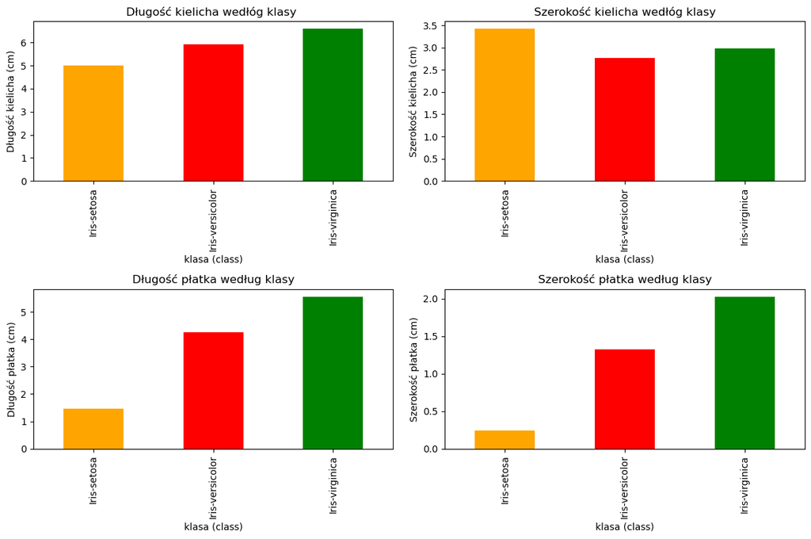

### Na powyższym wykresie widać, że:

### Przeciętny Iris Setosa ma najkrótszy kielich, a przeciętny Iris Virginica najdłuższy.

### Przeciętny Iris Setosa ma najszerszy kielich, a przeciętny Iris Versicolor najwęższy.

### Przeciętny Iris Setosa ma najmniejsze płatki, a przeciętny Iris Virginica największe.

## KROK 4

#### Uzupełnianie brakujacych danych

#### Krok pominięty, dane sa kompletne

## KROK 5

#### Relacje i zależności pomiędzy kolumnami

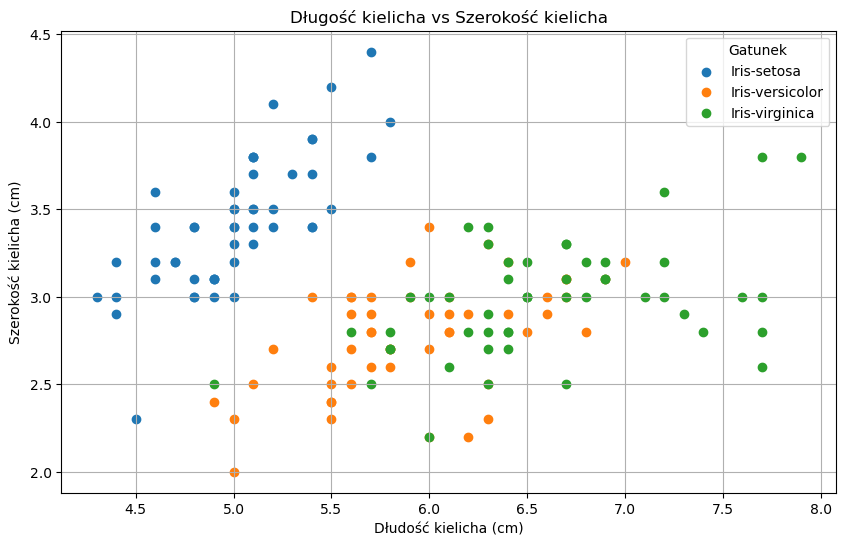

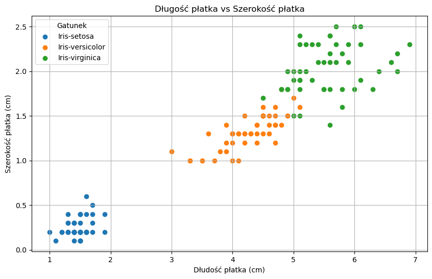

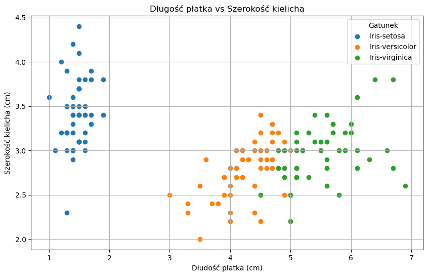

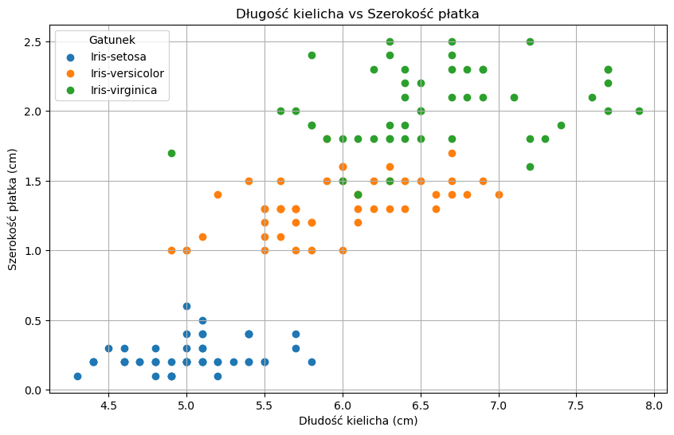

```
<function matplotlib.pyplot.show(close=None, block=None)>
```

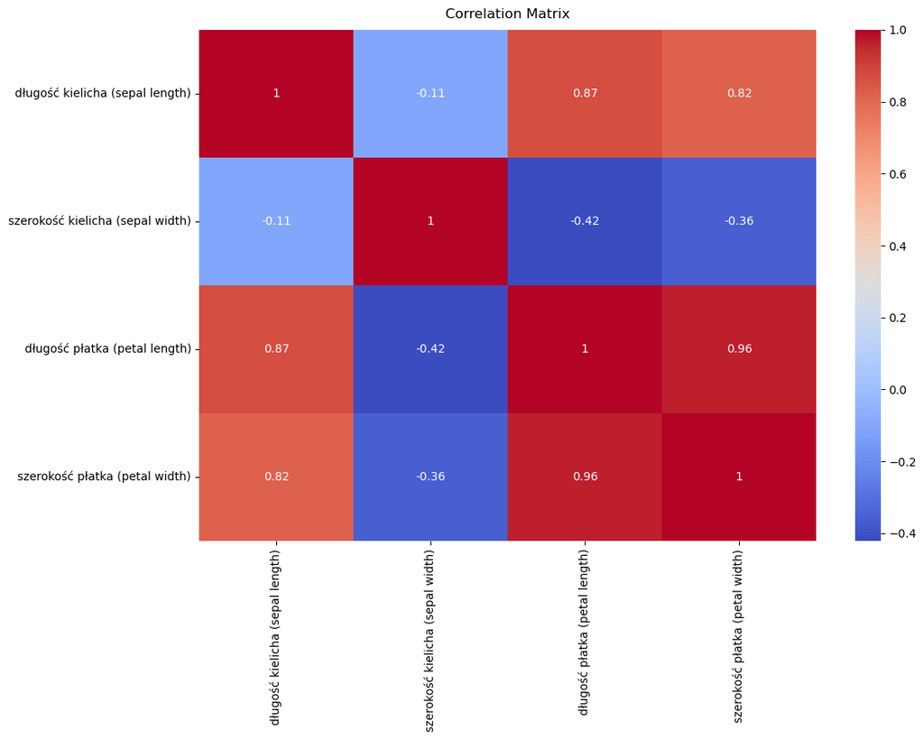

#### Na podstawie powyższych wykresów oraz macierzy korelacji:

1. Występuje silna zaleznosc pomiędzy długościa płatka i szerokościa płatka (0,96) - dluższe płatki to i szersze płatki
2. Występuje silna zależność pomiędzy długościa kielicha i długościa płatka (0,87) oraz szerokościa płatka (0,82) - dłuższe kielichy maja dłuższe i szersze płatki
3. Zależność pomiędzy długościa kielicha i szerokość kielicha wynosi -0,11 co wskazuje na brak korelacji
4. Szerokość kielicha i szerokość płatka oraz długość płatka maja niewielką korelację ujemna (-0,36 i -0,42) - szerszy kielich jest zwiazany z węższymi i krótszymi płatkami.

## KROK 6

#### Badanie wartości odstajacych

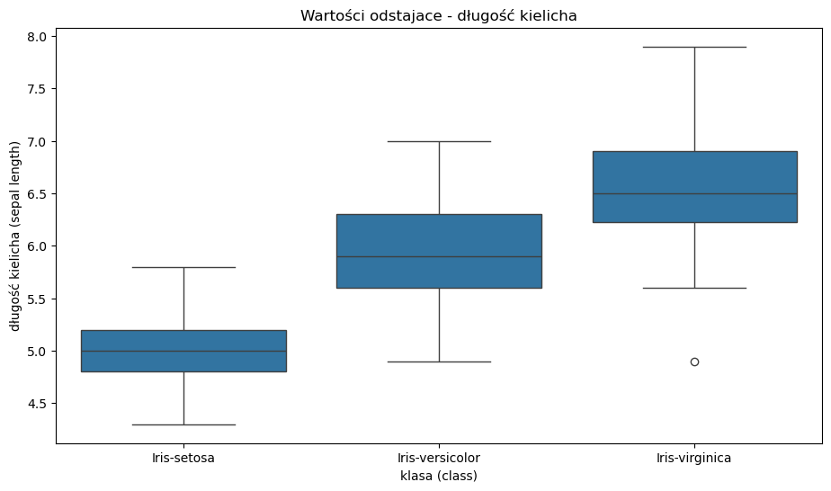

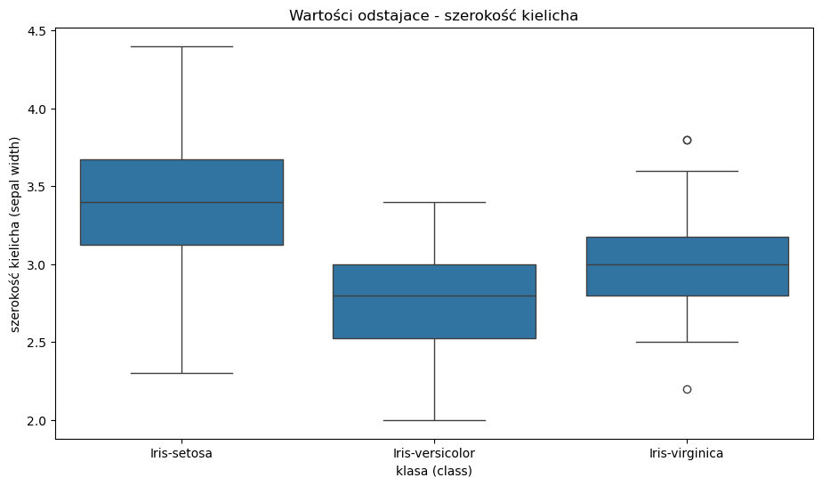

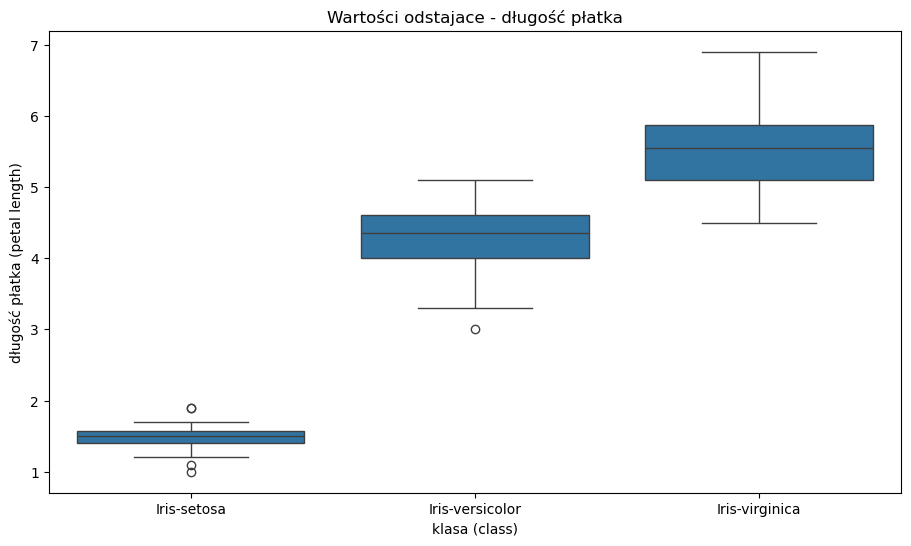

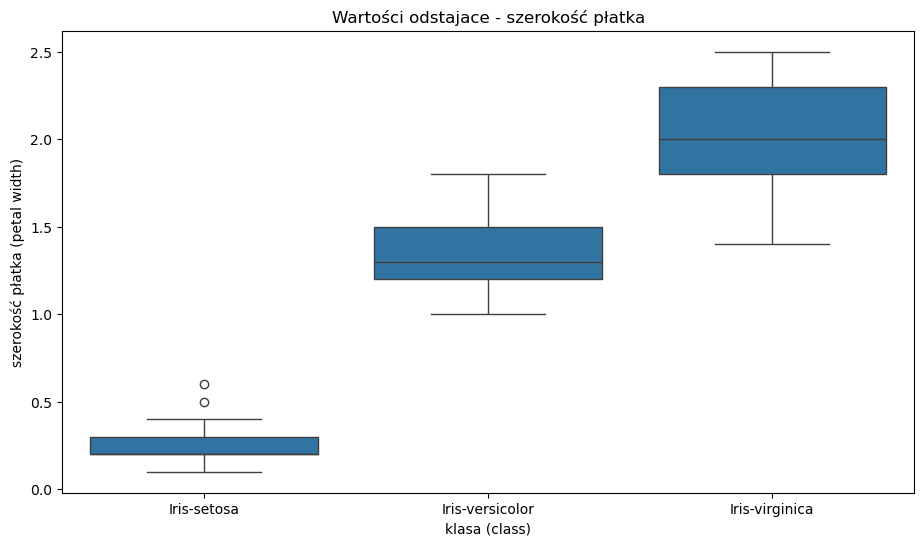

### Na podstawie powyższych wykresów możemy zaobserwować:

1. Iris virginica ma najdłuższe kielichy, wśród tych wartości wystapiła jedna odstajaca poniżej minimum- kwiat mógł być zmutowany, ewentualnie jeden egzemplarz został błędnie zmierzony, wprowadzony lub sklasyfikowany.
2. Najszersze kielichy ma Iris setosa, dla Iris virginica pojawia się jedna wartość powyżej maksimum i jedna poniżej minimum - niewykluczone, że oba egzemplarze były zmutowane, ewentualnie zostały błędnie zmierzone, wprowadzone lub sklasyfikowane.
3. Najdłuższe płatki ma Iris virginica, dla Iris versicolor wystapiła jedna wartość odstajaca poniżej minimum, a dla Iris setosa dwie wartości poniżej minimum i jedna powyżej maksimum dla tej klasy kwiatów.
4. Najszersze płatki również ma Iris virginica - tutaj wartości odstajace pojawiaja się dla Iris setosa - dwie powyżej maksimum.
5. Iris setosa jest łatwo odróżnialny od pozostałych gatunków, szczególnie na podstawie wymiarów płatków.
6. Iris versicolor i Iris virginica są trudniejsze do rozróżnienia, ponieważ ich cechy częściowo się pokrywają.
7. Wymiary płatków (długość i szerokość) są lepszymi cechami do rozróżniania gatunków niż wymiary kielicha.
8. Najwyższą korelację obserwujemy między długością i szerokością płatków.